# Modeling binary data

13 May 2026

## Goals for today

- Understand the characteristics of binary data and the Bernoulli distribution
- Understand how to model binary data with logistic regression
- Understand approaches to inference in logistic regression
- Understand diagnostic measures for logistic regression

## Bernoulli distribution

The Bernoulli distribution describes the probability of a single “event” \(y_i\) occurring

- present (1/1) or absent (0/1)
- alive (1/1) or dead (0/1)
- mature (1/1) or immature (0/1)

## Binomial distribution

The binomial distribution is closely related to the Bernoulli

It describes the number of \(k\) “successes” in a sequence of \(n\) independent Bernoulli “trials”

For example, the number of heads in 4 coin tosses

## Binomial distribution

For a population, these could be

- \(k\) survivors out of \(n\) tagged individuals
- \(k\) infected individuals out of \(n\) susceptible individuals
- \(k\) counts of allele A in \(n\) total chromosomes

## Binomial distribution

The probability mass function

\[ \Pr(k; n, p) = \left( \begin{array}{c} n \\ k \end{array} \right) p^k (1 - p)^{n - k} \\ ~ \\ \left( \begin{array}{c} n \\ k \end{array} \right) = \frac{n!}{k!(n - k)!} \]

## Bernoulli distribution

Special case of binomial with \(n = 1\)

\[ \Pr(k; n, p) = \left( \begin{array}{c} n \\ k \end{array} \right) p^k (1 - p)^{n - k} \\ \Downarrow \\ \Pr(k; p) = p^k (1 - p)^{(1 - k)} \\ \Downarrow \\ k = \left\{ \begin{array}{l} 1 ~ \text{if success (T, Y) with probability }p \\ 0 ~ \text{if failure (F, N) with probability }(1 - p) \end{array} \right. \]

## Bernoulli distribution

\[ \Pr(k; p) = p^k (1 - p)^{(1 - k)} \\ \Downarrow \\ k = \left\{ \begin{array}{l} 1 ~ \text{if success (T, Y) with probability }p \\ 0 ~ \text{if failure (F, N) with probability }(1 - p) \end{array} \right. \]

where

\[ \text{Mean}(k) = p ~ ~ ~ ~ ~ \text{Var}(k) = p(1 - p) \]

## Bernoulli distribution

### Likelihood

\[ \mathcal{L}(k; p) = \prod_{i = 1}^n p^{k_i} (1 - p)^{(1 - k_i)} \\ \Downarrow \\ \log \mathcal{L}(k; p) = \log p \sum_{i = 1}^{n} k_{i} + \log (1-p) \sum_{i = 1}^{n} \left( 1 - k_{i} \right) \]

## Bernoulli distribution

Canonical link is the logit

\[ \log \left( \frac{\mu}{1 - \mu} \right) = \mathbf{X} \boldsymbol{\beta} \\ \Downarrow \\ \mu = \frac{\exp (\mathbf{X} \boldsymbol{\beta})}{1 + \exp (\mathbf{X} \boldsymbol{\beta})} \]

## Logit link

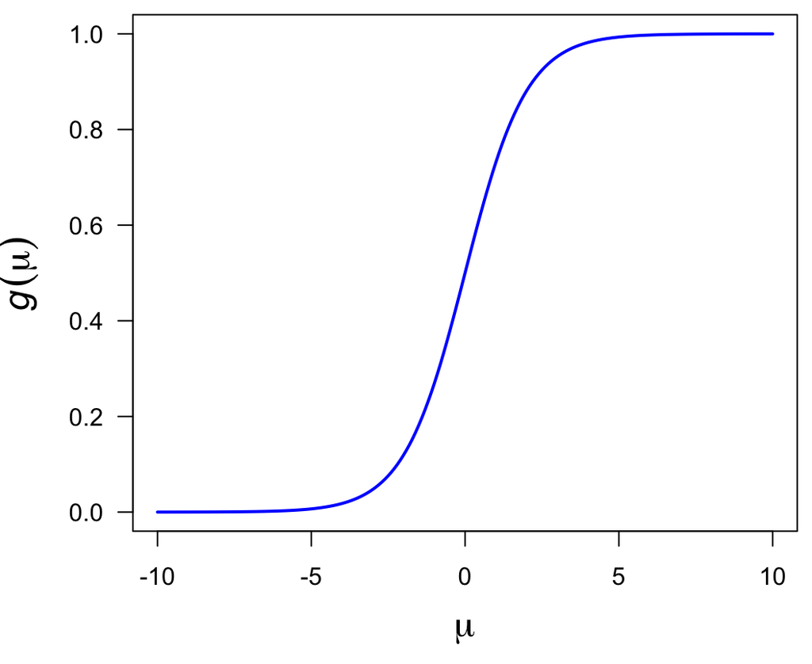

## Logistic regression

Similar to other regression in that we assume

- the predictors are linear
- the observations are independent of one another
- no(ish) multicollinearity among predictors

## Logistic regression

Different from other regression in that

- the response is binary
- the relationship between response and predictors is often non-linear
- the errors can be non-normal
- the errors can be heteroscedastic

## Logistic regression is a GLM

We need 3 things to specify our GLM

1. Distribution of the data: \(y \sim \text{Bernoulli}(p)\)
2. Link function: \(\text{logit}(p) = \log \left( \frac{p}{1 - p} \right) = \eta\)
3. Linear predictor: \(\eta = \mathbf{X} \boldsymbol{\beta}\)

## Logistic regression

The probability of a success is given by

\[ \begin{align} p &= \frac{\exp(\mathbf{X} \boldsymbol{\beta})}{1 + \exp(\mathbf{X} \boldsymbol{\beta})} \\ ~ \\ &= \frac{1}{1 + \exp(\text{-} \mathbf{X} \boldsymbol{\beta})} \end{align} \]

## Logistic regression

### Example

Sockeye salmon are born in freshwater and rear there for some time before migrating to the ocean as *smolts*

The age at which sockeye smolt can vary from 1 to 2 years, which is thought to depend on their body size

Let’s examine the relationship between fish length and its probability of smolting at age-2 instead of age-1

## Smolt age versus length

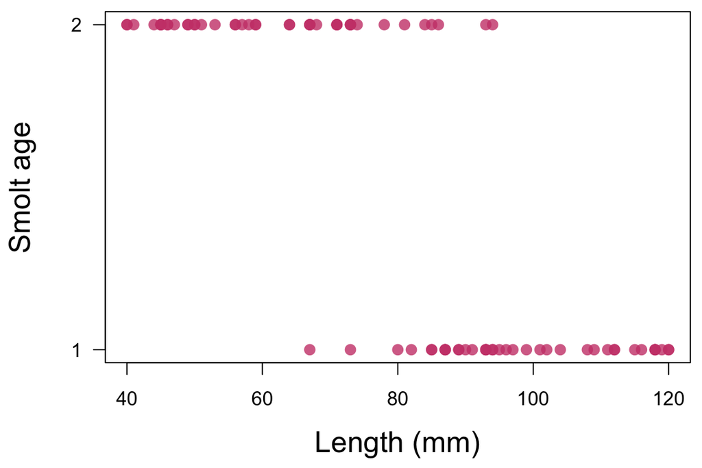

## Smolt age versus length

In **R** we use `glm()` to fit logistic regression models (and other GLMs)

```r
## fit model with glm
fit_mod <- glm(age ~ length, data = df,
               family = binomial(link = "logit"))
faraway::sumary(fit_mod)
```

```
##              Estimate Std. Error z value  Pr(>|z|)
## (Intercept) 14.216166   3.417816  4.1594 3.190e-05
## length      -0.173990   0.041051 -4.2383 2.252e-05
##
## n = 80 p = 2
## Deviance = 39.91950 Null Deviance = 110.70347 (Difference = 70.78396)
```

## Smolt age versus length

The probability of smolting at age-2 is given by

## Smolt age versus length

We can get the fitted values with `predict()`

```r
## get fitted values
newdata <- data.frame(length = seq(40, 120))
p_hat <- 1 / (1 + exp(-predict(fit_mod, newdata)))
```

## Smolt age versus length

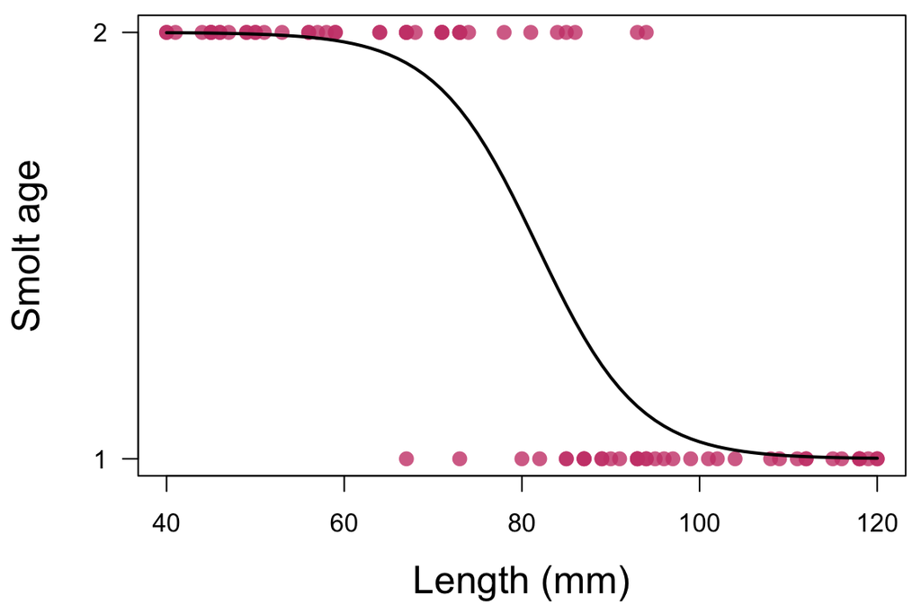

## Smolt age versus length

What is the length at which the probability of smolting at age-2 is 0.5?

## Logistic regression and odds

We have talked a bit about odds with respect to evidence ratios

Odds \(o\) are an unbounded alternative to probability \(p\)

If we represent the \(k\)-to-1 odds against something as \(1 / k\), then the following holds

## Logistic regression and odds

\[ \text{logit}(p) = \mathbf{X} \boldsymbol{\beta} \\ \Downarrow \\ \log \left( \frac{p}{1 - p} \right) = \mathbf{X} \boldsymbol{\beta} \\ \Downarrow \\ \log ( \text{odds} ) = \mathbf{X} \boldsymbol{\beta} \\ \Downarrow \\ \text{odds} = \exp (\mathbf{X} \boldsymbol{\beta}) \]

## Smolt age versus length

```r
## our fitted model
faraway::sumary(fit_mod)
```

```
##              Estimate Std. Error z value  Pr(>|z|)
## (Intercept) 14.216166   3.417816  4.1594 3.190e-05
## length      -0.173990   0.041051 -4.2383 2.252e-05
##
## n = 80 p = 2
## Deviance = 39.91950 Null Deviance = 110.70347 (Difference = 70.78396)
```

## QUESTIONS?

## Inference

Consider 2 models, A & B, such that B is a subset of A

A = \(f(x_1, x_2)\)

B = \(g(x_1)\)

We have seen that we can compare A & B via a likelihood ratio test

\[ \lambda = \text{-}2 \log \frac{\mathcal{L}_A}{\mathcal{L}_B} \sim \chi^2_{df = k_A - k_B} \]

## Log-likelihood

The log-likelihood using a logit link is

\[ \log \mathcal{L}(k; p) = \log p \sum_{i = 1}^{n} k_{i} + \log (1-p) \sum_{i = 1}^{n} \left( 1 - k_{i} \right) \]

## Deviance

Deviance \(D\) is a goodness-of-fit statistic

It’s a generalization of using the sum-of-squares of residuals in ordinary least squares to cases where model-fitting is achieved by maximum likelihood

\[ D = \text{-}2 \log \mathcal{L} \]

## Deviance for logistic regression

\[ \begin{align} D &= \text{-}2 \left[ \log p \sum_{i = 1}^{n} k_{i} + \log (1-p) \sum_{i = 1}^{n} \left( 1 - k_{i} \right) \right] \\ &= \text{-}2 \sum_{i = 1}^{n} \left[ p_i \text{logit}(p_i) + \log (1 - p_i) \right] \end{align} \]

## Likelihood ratio test

\[ \lambda = \text{-}2 \log \frac{\mathcal{L}_A}{\mathcal{L}_B} \sim \chi^2_{df = k_A - k_B} \\ \Downarrow \\ \lambda = \text{-}2 (\log \mathcal{L}_A - \log \mathcal{L}_B) \sim \chi^2_{df = k_A - k_B} \\ \Downarrow \\ \lambda = D(B) - D(A) \sim \chi^2_{df = k_A - k_B} \]

## Smolt age versus length

The output from `glm()` includes the deviances for the full model and a null model with no predictors

```r
## our fitted model
faraway::sumary(fit_mod)
```

```
##              Estimate Std. Error z value  Pr(>|z|)
## (Intercept) 14.216166   3.417816  4.1594 3.190e-05
## length      -0.173990   0.041051 -4.2383 2.252e-05
##
## n = 80 p = 2
## Deviance = 39.91950 Null Deviance = 110.70347 (Difference = 70.78396)
```

## Smolt age versus length

Likelihood ratio test for \(H_0 : \beta_1 = 0\)

```r
## deviance of full model
D_full <- summary(fit_mod)$deviance
## deviance of null model
D_null <- summary(fit_mod)$null.deviance
## test statistic
lambda <- D_null - D_full
## LRT with df = 1
(p_value <- pchisq(lambda, 1, lower.tail = FALSE))
```

```
## [1] 3.985637e-17
```

## Model selection via AIC

\[ \begin{align} AIC &= 2 k - 2 \log \mathcal{L} \\ &= 2 k + D \end{align} \]

```r
## AIC
AIC(fit_mod)
## AIC via likelihood
(2 * 2) - 2 * logLik(fit_mod)
## AIC via deviance
(2 * 2) + summary(fit_mod)$deviance
```

```
## [1] 43.9195
## 'log Lik.' 43.9195 (df=2)
## [1] 43.9195
```

## Smolt age versus length

Compare to a null model with no predictors

```r
## fit null model
fit_null <- glm(age ~ 1, data = df,
                family = binomial(link = "logit"))
faraway::sumary(fit_null)
```

```
##             Estimate Std. Error z value Pr(>|z|)
## (Intercept)  0.10008    0.22389   0.447   0.6549
##
## n = 80 p = 1
## Deviance = 110.70347 Null Deviance = 110.70347 (Difference = 0.00000)
```

## Model selection via AIC

```r
## difference in AIC
AIC(fit_null) - AIC(fit_mod)
```

```
## [1] 68.78396
```

## Significance test for \(\beta_i\)

An alternative to the \(\chi^2\) test is a \(z\) test

\[ z = \frac{\hat{\beta_i}}{\text{SE}(\hat{\beta_i})} \sim z_{\alpha / 2} \]

## Significance test for \(\beta_i\)

```r
## summary table
faraway::sumary(fit_mod)
```

```
##              Estimate Std. Error z value  Pr(>|z|)
## (Intercept) 14.216166   3.417816  4.1594 3.190e-05
## length      -0.173990   0.041051 -4.2383 2.252e-05
##
## n = 80 p = 2
## Deviance = 39.91950 Null Deviance = 110.70347 (Difference = 70.78396)
```

## Confidence interval for \(\beta_i\)

We can also compute a 100(1 - \(\alpha\))% confidence interval

\[ \hat{\beta_i} \pm z_{\alpha / 2} \text{SE}(\hat{\beta_i}) \]

## Confidence interval for \(\beta_i\)

```r
## beta
beta_1 <- coef(fit_mod)[2]
## SE of beta
se_beta_1 <- sqrt(diag(vcov(fit_mod)))[2]
## 95% CI
beta_1 + c(-1,1) * 1.96 * se_beta_1
```

```
## [1] -0.25445073 -0.09352909
```

## Confidence interval for \(\beta_i\)

Due to possible bias in \(\text{SE}(\beta)\), we can compute CI’s based on the *profile likelihood*

```r
## number of points to profile
nb <- 200
## possible beta's
beta_hat <- seq(-0.4, 0, length = nb)
## calculate neg-LL of possible beta's
pl <- rep(NA, nb)
for(i in 1:nb) {
  mm <- glm(age ~ 1 + offset(beta_hat[i] * length), data = df,
            family = binomial(link = "logit"))
  pl[i] <- -logLik(mm)
}
```

## Confidence interval for \(\beta_i\)

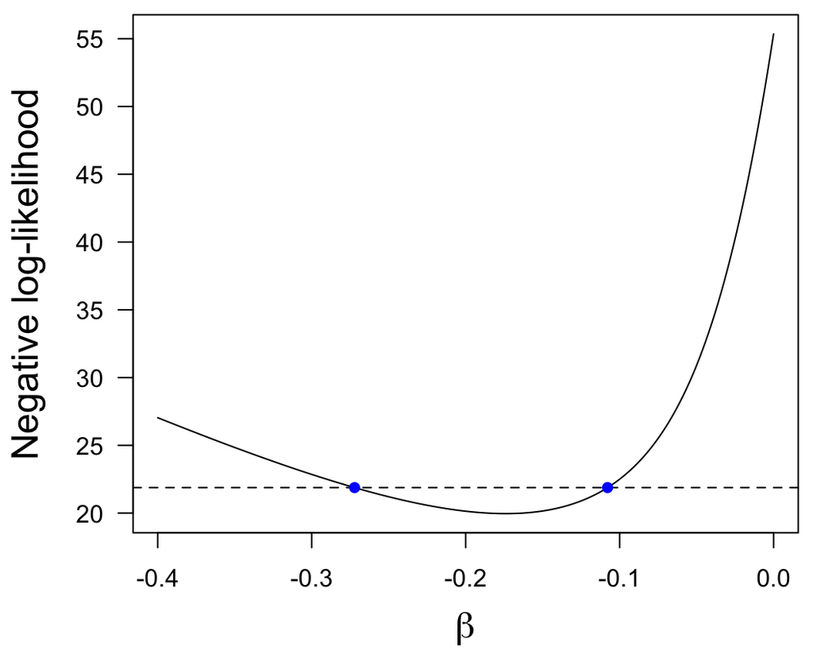

## Confidence interval for \(\beta_i\)

We can compute CI’s based on the profile likelihood with `confint()`

```r
## 95% CI via profile likelihood
confint(fit_mod)
```

```
##                 2.5 %     97.5 %
## (Intercept)  8.730190 22.4253100
## length      -0.272113 -0.1078227
```

## Model diagnostics

As with other models, it’s important to examine diagnostic checks for our fitted models

## Residuals

We usually think about residuals \(e\) as

\[ e = y - \hat{y} \]

With logistic regression, the response can take 1 of 2 possible values

## Residuals

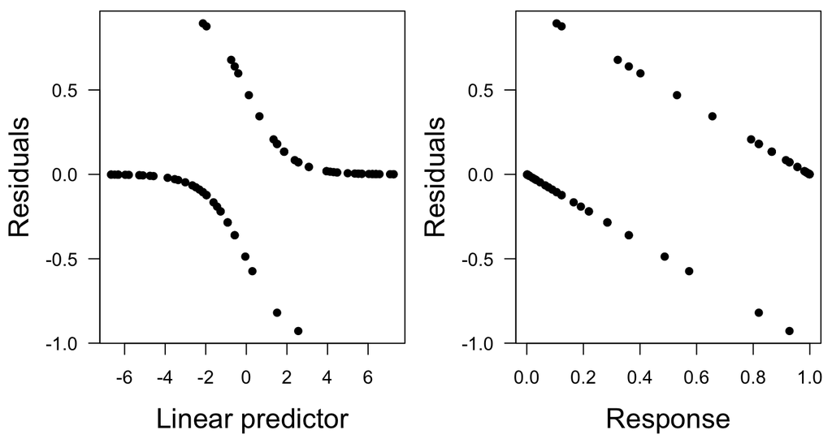

## Deviance residuals

We can instead use the *deviance residuals*

\[ e_i = (2 y_i - 1) D_i \]

\(2 y - 1\) is 1 (-1) if y is 1 (0)

This is the default for `residuals()`

## Deviance residuals

We then place the deviance residuals into bins for easier inspection

- Sensitive to the number of bins (~30/bin is good)
- Mean of \(e\) not constrained to 0
- Check to see that ~95% of points fall within the CI

Can use `binnedplot()` from the **arm** package to do this

## Deviance residuals

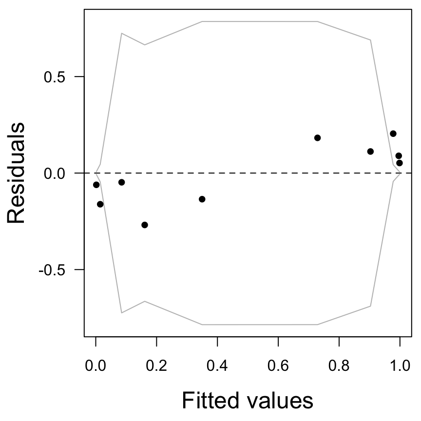

## \(Q\)-\(Q\) plots

We can examine a \(Q\)-\(Q\) plot, but there is no assumption that the \(e\) are normal

It can help to identify unusual points

## \(Q\)-\(Q\) plots

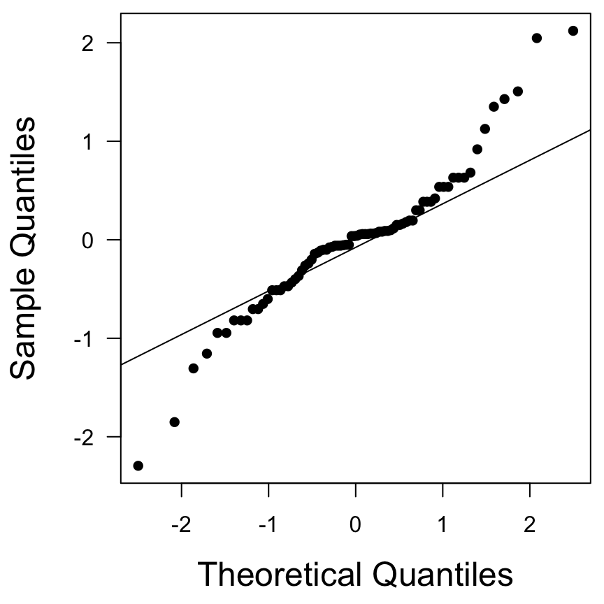

## Leverage

We can also calculate the leverages \(h\) to look for unusual observation in *predictor space*

Recall we are potentially concerned about \(h > 2 \frac{k}{n}\)

We can use `faraway::halfnorm()`

## Leverage

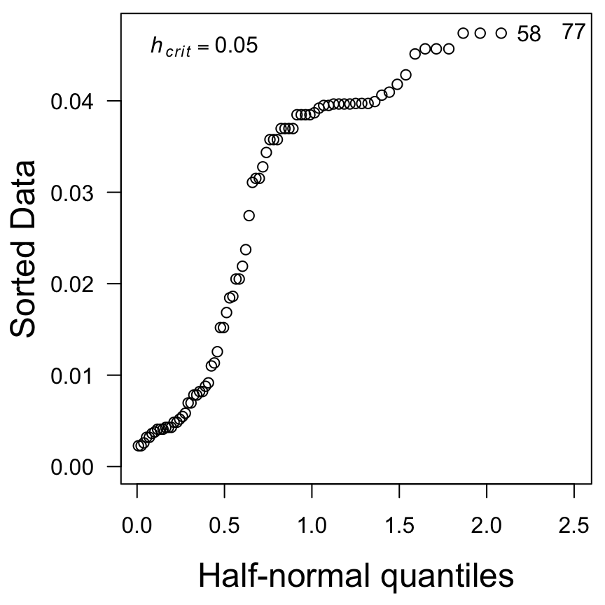

## Cook’s Distance

Recall that we can use Cook’s \(D\) to identify potentially influential points

\[ D_{i}=e_{i}^{2} \frac{1}{k}\left(\frac{h_{i}}{1-h_{i}}\right) \]

## Cook’s Distance

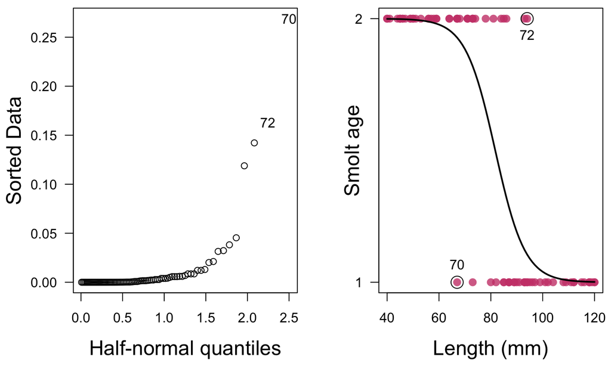